# Stat184 Class Poject - DEI Analysis

**Research Question:**  
*How does gender and ethnicity representation, hiring, and attrition vary across different regions?*

### Primary Dataset

- **Source:** Google Diversity Annual Report data accessed through Google BigQuery
- **Collected by:** Google Inc.
- **When & Why:** Published annually to provide info around workforce demographics and support DEI efforts within the company
- **What is a case?** Each row represents a demographic group such as gender in a given region, along with a specific workforce metric such as hiring, exits, representation, or attrition
- **Variables of interest:**
- **Region: The global region of the workforce segment**
- **Gender or Ethnicity: The demographic group represented**
- **Hiring, Representation, Exits, Attrition Index: The workforce metric value, depending on the dataset**

### Secondary Dataset

- **Source:** American Community Survey (ACS) 5-Year Estimates accessed via the `tidycensus` package in R
- **Collected by:** U.S. Census Bureau
- **When & Why:** The ACS is collected annually to provide critical demographic, social, economic, and housing data across U.S. regions. This data helps contextualize diversity metrics, such as gender and racial/ethnic representation, in broader U.S. labor markets.
- **What is a case?** Each case represents a region (e.g., West, Midwest, South, Northeast) or state, along with aggregated population estimates by race, gender, and education level.
- **Number of Cases:** Varies depending on granularity (e.g., ~50 states or 4 census regions), filtered down based on focus
- **Variables of interest:**
  - Total population by gender
  - Total population by race/ethnicity
  - Percent of population with a bachelor’s degree or higher (for pipeline comparison)

```r
library(tidyverse)
library(ggplot2)
library(tidycensus)
```

```r
#API for Tidycensus,PERSONAL REMINDER TO HIDE FROM PROD!!!!!
census_api_key("MY API HERE", install = TRUE) #Hiding upon submitting for safety & best practice reasons.
```

```r
# Load region-level workforce metrics
region_rep <- read_csv("data-sets/region-non-intersectional-representation.csv")
region_hire <- read_csv("data-sets/region-non-intersectional-hiring.csv")
region_exit <- read_csv("data-sets/region-non-intersectional-exits-representation.csv")
region_attrition <- read_csv("data-sets/region-non-intersectional-attrition-index.csv")
```

```r
glimpse(region_rep)
```

```
Rows: 24
Columns: 11
$ workforce                   <chr> "leadership", "leadership", "leadership", "leadership", "tech", "tech", "overall", "overall", "non_tech", "non_tech", "non_tech", "overall", "non_te…
$ report_year                 <dbl> 2021, 2022, 2021, 2022, 2022, 2021, 2022, 2021, 2022, 2021, 2021, 2021, 2022, 2022, 2021, 2022, 2022, 2021, 2021, 2022, 2022, 2021, 2021, 2022
$ region                      <chr> "APAC", "APAC", "EMEA", "EMEA", "APAC", "APAC", "APAC", "APAC", "APAC", "APAC", "EMEA", "EMEA", "EMEA", "EMEA", "EMEA", "EMEA", "AMERICAS (non-US)",…
$ race_asian                  <dbl> 0.708, 0.721, 0.066, 0.066, 0.915, 0.892, 0.888, 0.858, 0.855, 0.820, 0.105, 0.109, 0.111, 0.121, 0.113, 0.130, 0.339, 0.304, 0.218, 0.233, NA, NA, …
$ race_black_african          <dbl> NA, NA, 0.033, 0.038, 0.003, 0.004, 0.003, 0.005, 0.004, 0.005, 0.037, 0.028, 0.043, 0.032, 0.019, 0.023, 0.038, 0.032, 0.039, 0.049, NA, NA, 0.046,…
$ race_hispanic_latino_latinx <dbl> NA, NA, NA, NA, 0.006, 0.007, 0.008, 0.011, 0.011, 0.016, 0.036, 0.038, 0.038, 0.039, 0.039, 0.040, 0.178, 0.192, 0.333, 0.341, 0.409, 0.438, 0.450,…
$ race_indigenous             <dbl> NA, NA, NA, NA, 0.001, NA, 0.002, 0.002, 0.002, 0.003, 0.004, 0.003, 0.004, 0.003, 0.003, 0.003, 0.007, 0.008, 0.010, 0.008, NA, NA, 0.012, 0.009
$ race_mena                   <dbl> NA, NA, 0.045, 0.058, 0.004, 0.005, 0.005, 0.006, 0.006, 0.007, 0.067, 0.073, 0.069, 0.078, 0.079, 0.085, 0.063, 0.065, 0.048, 0.047, NA, NA, 0.033,…
$ race_white_european         <dbl> 0.288, 0.279, 0.877, 0.858, 0.084, 0.106, 0.110, 0.138, 0.141, 0.173, 0.803, 0.804, 0.786, 0.781, 0.805, 0.777, 0.462, 0.501, 0.482, 0.436, 0.523, 0…
$ gender_women                <dbl> 0.292, 0.318, 0.269, 0.297, 0.235, 0.225, 0.353, 0.346, 0.453, 0.443, 0.444, 0.327, 0.454, 0.338, 0.210, 0.227, 0.235, 0.204, 0.310, 0.334, 0.343, 0…
$ gender_men                  <dbl> 0.708, 0.682, 0.731, 0.703, 0.765, 0.775, 0.647, 0.654, 0.547, 0.557, 0.556, 0.673, 0.546, 0.662, 0.790, 0.773, 0.765, 0.796, 0.690, 0.666, 0.657, 0…
```

```r
summary(region_rep)
```

```
  workforce          report_year      region            race_asian     race_black_african race_hispanic_latino_latinx race_indigenous      race_mena       race_white_european
 Length:24          Min.   :2021   Length:24          Min.   :0.0660   Min.   :0.00300    Min.   :0.00600             Min.   :0.001000   Min.   :0.00400   Min.   :0.0840
 Class :character   1st Qu.:2021   Class :character   1st Qu.:0.1150   1st Qu.:0.00500    1st Qu.:0.01475             1st Qu.:0.003000   1st Qu.:0.00675   1st Qu.:0.2525
 Mode  :character   Median :2022   Mode  :character   Median :0.2255   Median :0.03200    Median :0.03900             Median :0.003000   Median :0.04750   Median :0.4745
                    Mean   :2022                      Mean   :0.4032   Mean   :0.02700    Mean   :0.15500             Mean   :0.004941   Mean   :0.04390   Mean   :0.4832
                    3rd Qu.:2022                      3rd Qu.:0.7953   3rd Qu.:0.03825    3rd Qu.:0.33500             3rd Qu.:0.008000   3rd Qu.:0.06750   3rd Qu.:0.7823
                    Max.   :2022                      Max.   :0.9150   Max.   :0.05900    Max.   :0.47000             Max.   :0.012000   Max.   :0.08500   Max.   :0.8770
                                                      NA's   :2        NA's   :4          NA's   :4                   NA's   :7          NA's   :4
  gender_women      gender_men
 Min.   :0.2040   Min.   :0.5460
 1st Qu.:0.2605   1st Qu.:0.6360
 Median :0.3225   Median :0.6775
 Mean   :0.3232   Mean   :0.6768
 3rd Qu.:0.3640   3rd Qu.:0.7395
 Max.   :0.4540   Max.   :0.7960
```

```r
head(region_rep)
```

| workforce | report_year | region | race_asian | race_black_african | race_hispanic_latino_latinx | race_indigenous | race_mena | race_white_european | gender_women | gender_men |
| --- | --- | --- | --- | --- | --- | --- | --- | --- | --- | --- |
| leadership | 2021 | APAC | 0.708 | NA | NA | NA | NA | 0.288 | 0.292 | 0.708 |
| leadership | 2022 | APAC | 0.721 | NA | NA | NA | NA | 0.279 | 0.318 | 0.682 |
| leadership | 2021 | EMEA | 0.066 | 0.033 | NA | NA | 0.045 | 0.877 | 0.269 | 0.731 |
| leadership | 2022 | EMEA | 0.066 | 0.038 | NA | NA | 0.058 | 0.858 | 0.297 | 0.703 |
| tech | 2022 | APAC | 0.915 | 0.003 | 0.006 | 0.001 | 0.004 | 0.084 | 0.235 | 0.765 |
| tech | 2021 | APAC | 0.892 | 0.004 | 0.007 | NA | 0.005 | 0.106 | 0.225 | 0.775 |

```r
glimpse(region_hire)
```

```
Rows: 24
Columns: 5
$ workforce    <chr> "overall", "tech", "non_tech", "leadership", "overall", "tech", "non_tech", "leadership", "overall", "tech", "non_tech", "leadership", "overall", "tech", "non_tech…
$ report_year  <dbl> 2021, 2021, 2021, 2021, 2022, 2022, 2022, 2022, 2021, 2021, 2021, 2021, 2022, 2022, 2022, 2022, 2021, 2021, 2021, 2021, 2022, 2022, 2022, 2022
$ region       <chr> "AMERICAS (non-US)", "AMERICAS (non-US)", "AMERICAS (non-US)", "AMERICAS (non-US)", "AMERICAS (non-US)", "AMERICAS (non-US)", "AMERICAS (non-US)", "AMERICAS (non-U…
$ gender_women <dbl> 0.285, 0.232, 0.341, NA, 0.358, 0.271, 0.406, NA, 0.364, 0.250, 0.433, 0.208, 0.372, 0.249, 0.468, 0.275, 0.339, 0.279, 0.389, 0.288, 0.385, 0.280, 0.492, 0.471
$ gender_men   <dbl> 0.715, 0.768, 0.659, 0.750, 0.642, 0.729, 0.594, NA, 0.636, 0.750, 0.567, 0.792, 0.628, 0.751, 0.532, 0.725, 0.661, 0.721, 0.611, 0.712, 0.615, 0.720, 0.508, 0.529
```

```r
summary(region_hire)
```

```
  workforce          report_year      region           gender_women     gender_men
 Length:24          Min.   :2021   Length:24          Min.   :0.208   Min.   :0.5080
 Class :character   1st Qu.:2021   Class :character   1st Qu.:0.276   1st Qu.:0.6130
 Mode  :character   Median :2022   Mode  :character   Median :0.340   Median :0.6610
                    Mean   :2022                      Mean   :0.338   Mean   :0.6659
                    3rd Qu.:2022                      3rd Qu.:0.388   3rd Qu.:0.7270
                    Max.   :2022                      Max.   :0.492   Max.   :0.7920
                                                      NA's   :2       NA's   :1
```

```r
head(region_hire)
```

| workforce | report_year | region | gender_women | gender_men |
| --- | --- | --- | --- | --- |
| overall | 2021 | AMERICAS (non-US) | 0.285 | 0.715 |
| tech | 2021 | AMERICAS (non-US) | 0.232 | 0.768 |
| non_tech | 2021 | AMERICAS (non-US) | 0.341 | 0.659 |
| leadership | 2021 | AMERICAS (non-US) | NA | 0.750 |
| overall | 2022 | AMERICAS (non-US) | 0.358 | 0.642 |
| tech | 2022 | AMERICAS (non-US) | 0.271 | 0.729 |

```r
glimpse(region_exit)
```

```
Rows: 18
Columns: 5
$ workforce    <chr> "overall", "overall", "overall", "tech", "tech", "tech", "non_tech", "non_tech", "non_tech", "overall", "overall", "overall", "tech", "tech", "tech", "non_tech", "…
$ report_year  <dbl> 2021, 2021, 2021, 2021, 2021, 2021, 2021, 2021, 2021, 2022, 2022, 2022, 2022, 2022, 2022, 2022, 2022, 2022
$ region       <chr> "AMERICAS (non-US)", "APAC", "EMEA", "AMERICAS (non-US)", "APAC", "EMEA", "AMERICAS (non-US)", "APAC", "EMEA", "AMERICAS (non-US)", "APAC", "EMEA", "AMERICAS (non-…
$ gender_women <dbl> 0.290, 0.280, 0.308, NA, 0.159, 0.171, 0.367, 0.339, 0.411, 0.213, 0.365, 0.316, 0.093, 0.198, 0.210, 0.329, 0.427, 0.394
$ gender_men   <dbl> 0.710, 0.720, 0.692, 0.900, 0.841, 0.829, 0.633, 0.661, 0.589, 0.787, 0.635, 0.684, 0.907, 0.802, 0.790, 0.671, 0.573, 0.606
```

```r
summary(region_exit)
```

```
  workforce          report_year      region           gender_women      gender_men
 Length:18          Min.   :2021   Length:18          Min.   :0.0930   Min.   :0.5730
 Class :character   1st Qu.:2021   Class :character   1st Qu.:0.2100   1st Qu.:0.6415
 Mode  :character   Median :2022   Mode  :character   Median :0.3080   Median :0.7010
                    Mean   :2022                      Mean   :0.2865   Mean   :0.7239
                    3rd Qu.:2022                      3rd Qu.:0.3650   3rd Qu.:0.7990
                    Max.   :2022                      Max.   :0.4270   Max.   :0.9070
                                                      NA's   :1
```

```r
head(region_exit)
```

| workforce | report_year | region | gender_women | gender_men |
| --- | --- | --- | --- | --- |
| overall | 2021 | AMERICAS (non-US) | 0.290 | 0.710 |
| overall | 2021 | APAC | 0.280 | 0.720 |
| overall | 2021 | EMEA | 0.308 | 0.692 |
| tech | 2021 | AMERICAS (non-US) | NA | 0.900 |
| tech | 2021 | APAC | 0.159 | 0.841 |
| tech | 2021 | EMEA | 0.171 | 0.829 |

```r
glimpse(region_attrition)
```

```
Rows: 18
Columns: 5
$ workforce    <chr> "tech", "tech", "overall", "non_tech", "overall", "non_tech", "non_tech", "overall", "tech", "tech", "non_tech", "overall", "non_tech", "overall", "non_tech", "ove…
$ report_year  <dbl> 2021, 2022, 2022, 2022, 2021, 2021, 2021, 2021, 2021, 2022, 2022, 2022, 2022, 2022, 2021, 2021, 2022, 2021
$ region       <chr> "AMERICAS (non-US)", "AMERICAS (non-US)", "AMERICAS (non-US)", "AMERICAS (non-US)", "AMERICAS (non-US)", "AMERICAS (non-US)", "APAC", "APAC", "APAC", "APAC", "APAC…
$ gender_women <dbl> NA, 52, 66, 80, 97, 97, 75, 79, 79, 87, 90, 92, 85, 90, 91, 92, 93, 94
$ gender_men   <dbl> 108, 117, 117, 113, 101, 104, 118, 111, 106, 105, 104, 101, 115, 105, 105, 102, 102, 103
```

```r
summary(region_attrition)
```

```
  workforce          report_year      region           gender_women     gender_men
 Length:18          Min.   :2021   Length:18          Min.   :52.00   Min.   :101.0
 Class :character   1st Qu.:2021   Class :character   1st Qu.:79.00   1st Qu.:103.2
 Mode  :character   Median :2022   Mode  :character   Median :90.00   Median :105.0
                    Mean   :2022                      Mean   :84.65   Mean   :107.6
                    3rd Qu.:2022                      3rd Qu.:92.00   3rd Qu.:112.5
                    Max.   :2022                      Max.   :97.00   Max.   :118.0
                                                      NA's   :1
```

```r
head(region_attrition)
```

| workforce | report_year | region | gender_women | gender_men |
| --- | --- | --- | --- | --- |
| tech | 2021 | AMERICAS (non-US) | NA | 108 |
| tech | 2022 | AMERICAS (non-US) | 52 | 117 |
| overall | 2022 | AMERICAS (non-US) | 66 | 117 |
| non_tech | 2022 | AMERICAS (non-US) | 80 | 113 |
| overall | 2021 | AMERICAS (non-US) | 97 | 101 |
| non_tech | 2021 | AMERICAS (non-US) | 97 | 104 |

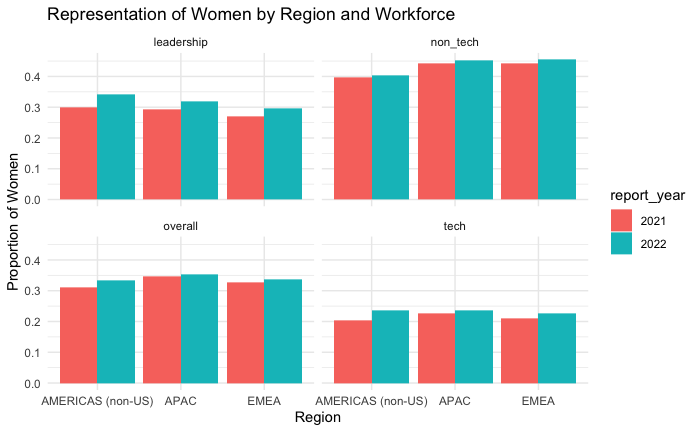

```r
region_rep <- region_rep %>%
  mutate(report_year = as.factor(report_year))

region_rep %>%
  ggplot(aes(x = region, y = gender_women, fill = report_year)) +
  geom_col(position = "dodge") +
  facet_wrap(~ workforce) +
  labs( title = "Representation of Women by Region and Workforce", x = "Region", y = "Proportion of Women") +
  theme_minimal()
```

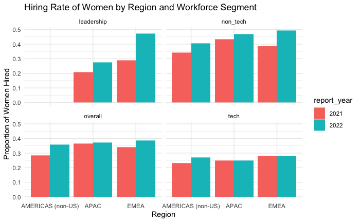

```r
region_hire <- region_hire %>%
  mutate(report_year = as.factor(report_year))

ggplot(region_hire, aes(x = region, y = gender_women, fill = report_year)) +
  geom_col(position = "dodge") +
  facet_wrap(~ workforce) +
  labs(title = "Hiring Rate of Women by Region and Workforce Segment",
       x = "Region", y = "Proportion of Women Hired") +
  theme_minimal()
```

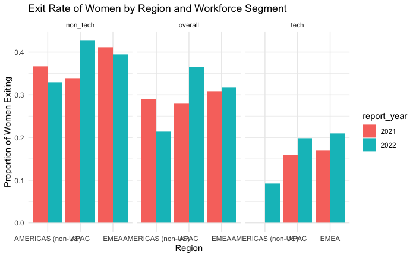

```r
region_exit <- region_exit %>%
  mutate(report_year = as.factor(report_year))

region_exit %>%
  ggplot(aes(x = region, y = gender_women, fill = report_year)) +
  geom_col(position = "dodge") +
  facet_wrap(~ workforce) +
  labs(
    title = "Exit Rate of Women by Region and Workforce Segment",
    x = "Region", y = "Proportion of Women Exiting"
  ) +
  theme_minimal()
```